# Assignment 1

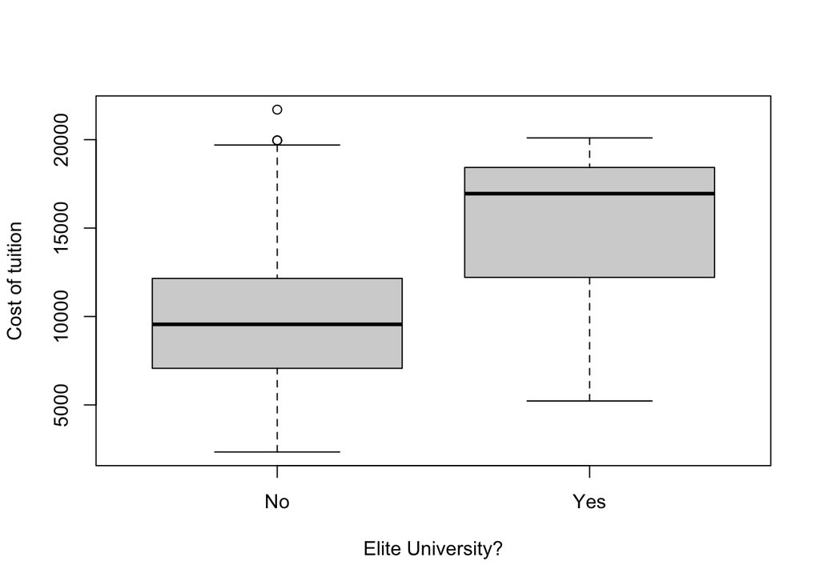

```r
plot(college$Elite, college$Outstate, xlab="Elite University?", ylab="Cost of tuition")
```

22. Use the hist() function to produce some histograms with differing numbers of bins for a few of the quantitative vari- ables. You may find the command par(mfrow=c(2,2)) useful: it will divide the print window into four regions so that four plots can be made simultaneously. Modifying the arguments to this function will divide the screen in other ways.

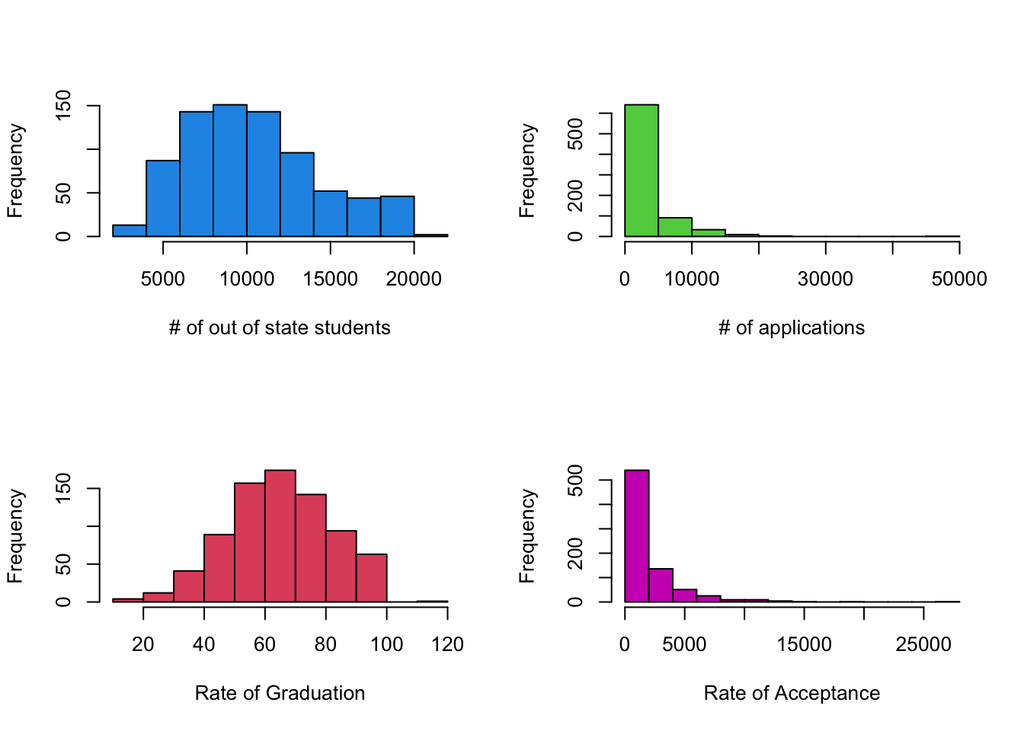

```r
# Fragmenting the display
par(mfrow=c(2,2))

# Creating the histograms
hist(college$Outstate, col = 4, xlab = "# of out of state students", main = "")
hist(college$Apps, col = 3, xlab = "# of applications", main = "")
hist(college$Grad.Rate, col = 2, xlab = "Rate of Graduation", main = "")
hist(college$Accept, col = 6, xlab = "Rate of Acceptance", main = "")
```

6. Continue exploring the data, and provide a brief summary of what you discover.

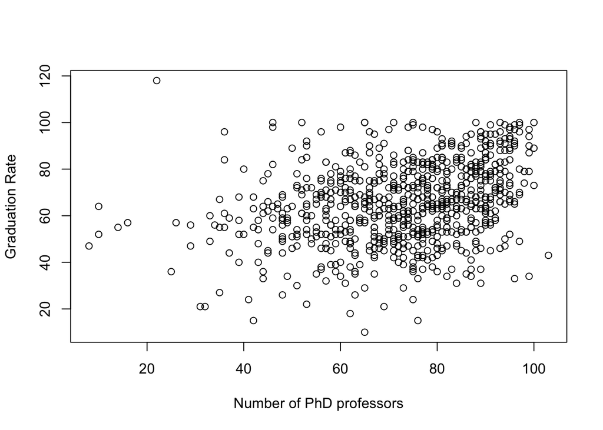

```r
# Number of PhD professors correlation to graduation rate
plot(college$PhD, college$Grad.Rate, xlab = "Number of PhD professors", ylab = "Graduation Rate")
```

```r
# School with highest amount from top 10 percent of high school class
row.names(college)[which.max(college$Top10perc)]
```

```
## [1] "Massachusetts Institute of Technology"
```